# Basic Generative Adversarial Network

This part of the project aims to develop a replication portfolio for the "Monster Index", which is constructed as a weighted combination of hedge funds.

**Main steps:**

1. **Data preparation**
   - Importing and cleaning historical financial data related to futures and hedge funds.
   - Normalizing prices and computing returns.
   - Constructing the Monster Index as a weighted combination of selected hedge funds.
2. **Latent feature extraction with Variational Autoencoder (VAE)**
   - Training a VAE to extract latent futures data, reducing dimensionality and capturing the most relevant features.
3. **Dataset Creation for time series models**
   - Preparing sliding window sequences to train GAN.
4. **Modeling with Generative Adversarial Network (GAN)**
   - Building and training a GAN with a GRU-based generator and a convolutional discriminator to, not only replicate, but also generate synthetic time series that replicate the normalized prices of the Monster Index.
5. **Model testing**
   - Assessing predictive performance on training and test sets using error metrics such as MSE and RMSE.
   - Computing risk metrics such as historical Value-at-Risk (VaR) based on the generated synthetic series.

**Differences from previous models:**

- Efficient synthetic replication of a complex financial index using advanced deep learning techniques.
- Combine latent feature extraction and sequential generation to enhance replication quality.

## Libraries and importing the dataset

```python
import pandas as pd
import numpy as np
import torch
import torch.nn as nn
from torch.utils.data import DataLoader, TensorDataset
import torch.nn.functional as F
import matplotlib.pyplot as plt
from sklearn.preprocessing import MinMaxScaler
from sklearn.metrics import mean_squared_error
import math
```

```python
file_path = './Dataset3_PortfolioReplicaStrategy.xlsx'

data_raw = pd.read_excel(file_path)
data_raw['Date'] = pd.to_datetime(data_raw['Ticker'], format='%d/%m/%Y')
data = data_raw.set_index('Date')



print("Dataset preview:")
display(data.head())
print("\nVariable Information (Bloomberg Ticker -> Full Name):")
print("\nDataset information:")
display(data.info())
print("\nBasic statistics:")
display(data.describe())
```

```
Dataset preview:
```

| Date | Ticker | MXWO | MXWD | LEGATRUU | HFRXGL | RX1 | TY1 | GC1 | CO1 | ES1 | VG1 | NQ1 | LLL1 | TP1 | DU1 | TU2 |
| --- | --- | --- | --- | --- | --- | --- | --- | --- | --- | --- | --- | --- | --- | --- | --- | --- |
| 2007-10-23 | 2007-10-23 | 1633.44 | 414.14 | 350.2138 | 1343.63 | 113.70 | 110.515625 | 759.0 | 82.85 | 1525.50 | 4393.0 | 2212.00 | 1287.0 | 1570.5 | 103.385 | 103.718750 |
| 2007-10-30 | 2007-10-30 | 1663.89 | 423.26 | 352.5413 | 1356.53 | 113.79 | 110.656250 | 787.8 | 87.44 | 1536.00 | 4476.0 | 2217.75 | 1323.9 | 1610.5 | 103.410 | 103.812500 |
| 2007-11-06 | 2007-11-06 | 1651.59 | 419.51 | 354.1758 | 1360.20 | 113.79 | 110.875000 | 823.4 | 93.26 | 1525.00 | 4425.0 | 2233.50 | 1320.0 | 1575.5 | 103.410 | 104.046875 |
| 2007-11-13 | 2007-11-13 | 1601.81 | 405.98 | 357.2217 | 1347.16 | 114.35 | 111.718750 | 799.0 | 88.83 | 1483.25 | 4323.0 | 2066.75 | 1271.0 | 1440.5 | 103.595 | 104.304688 |
| 2007-11-20 | 2007-11-20 | 1570.74 | 398.54 | 359.4446 | 1335.21 | 114.72 | 113.156250 | 791.4 | 95.49 | 1446.00 | 4296.0 | 2035.50 | 1225.2 | 1472.5 | 103.800 | 104.945312 |

```
Variable Information (Bloomberg Ticker -> Full Name):

Dataset information:
<class 'pandas.core.frame.DataFrame'>
DatetimeIndex: 705 entries, 2007-10-23 to 2021-04-20
Data columns (total 16 columns):
 #   Column    Non-Null Count  Dtype
---  ------    --------------  -----
 0   Ticker    705 non-null    datetime64[ns]
 1   MXWO      705 non-null    float64
 2   MXWD      705 non-null    float64
 3   LEGATRUU  705 non-null    float64
 4   HFRXGL    705 non-null    float64
 5   RX1       705 non-null    float64
 6   TY1       705 non-null    float64
 7   GC1       705 non-null    float64
 8   CO1       705 non-null    float64
 9   ES1       705 non-null    float64
 10  VG1       705 non-null    float64
 11  NQ1       705 non-null    float64
 12  LLL1      705 non-null    float64
 13  TP1       705 non-null    float64
 14  DU1       705 non-null    float64
 15  TU2       705 non-null    float64
dtypes: datetime64[ns](1), float64(15)
memory usage: 93.6 KB
```

```
None
```

```
Basic statistics:
```

|  | MXWO | MXWD | LEGATRUU | HFRXGL | RX1 | TY1 | GC1 | CO1 | ES1 | VG1 | NQ1 | LLL1 | TP1 | DU1 | TU2 |
| --- | --- | --- | --- | --- | --- | --- | --- | --- | --- | --- | --- | --- | --- | --- | --- |
| count | 705.00000 | 705.000000 | 705.000000 | 705.000000 | 705.000000 | 705.000000 | 705.000000 | 705.000000 | 705.000000 | 705.000000 | 705.000000 | 705.000000 | 705.000000 | 705.000000 | 705.000000 |
| mean | 1644.12566 | 404.151915 | 452.203206 | 1210.092071 | 147.278837 | 125.966977 | 1317.902837 | 77.018496 | 1960.443050 | 3072.167631 | 4526.981206 | 1064.444113 | 1277.263121 | 110.221277 | 108.627682 |
| std | 443.39041 | 100.980126 | 47.338067 | 73.965200 | 19.318527 | 6.295242 | 274.477979 | 26.794278 | 770.070634 | 473.812729 | 2900.866833 | 128.954655 | 353.598276 | 2.374875 | 1.532632 |
| min | 705.35000 | 176.100000 | 342.247100 | 1021.400000 | 110.200000 | 110.515625 | 732.700000 | 19.330000 | 689.500000 | 1873.000000 | 1072.000000 | 465.100000 | 704.000000 | 102.190000 | 103.718750 |
| 25% | 1293.43000 | 328.790000 | 431.737400 | 1158.150000 | 128.900000 | 121.203125 | 1178.000000 | 54.270000 | 1314.500000 | 2753.000000 | 2244.000000 | 1103.600000 | 905.000000 | 109.230000 | 107.871094 |
| 50% | 1646.69000 | 402.570000 | 456.728800 | 1215.200000 | 148.000000 | 126.000000 | 1283.000000 | 72.050000 | 1909.250000 | 3071.000000 | 3884.750000 | 1103.600000 | 1302.500000 | 110.855000 | 109.093750 |
| 75% | 1978.83000 | 478.410000 | 478.186800 | 1254.250000 | 163.240000 | 130.343750 | 1499.700000 | 105.780000 | 2569.750000 | 3433.000000 | 6333.250000 | 1103.600000 | 1587.500000 | 111.990000 | 109.906250 |
| max | 2944.05000 | 702.990000 | 559.311700 | 1415.110000 | 179.320000 | 140.328125 | 2001.200000 | 140.670000 | 4132.800000 | 4476.000000 | 13975.750000 | 1323.900000 | 1978.000000 | 112.720000 | 110.527344 |

## Data Preparation

```python
found_index=['MXWO','MXWD','LEGATRUU','HFRXGL']
futures=data.drop(columns=found_index)
found_index=['Ticker','MXWO','MXWD','LEGATRUU','HFRXGL']
hedge_fd=data.loc[:,found_index]

#Creation of a monster index
dates=hedge_fd.iloc[:,0]
#Getting the notmalized prices of the hedge founds
prices_hf=hedge_fd.iloc[:,1:]/hedge_fd.iloc[0,1:] #normalized prices
initial_price=hedge_fd.iloc[0,1:]

#Calculate the returns
returns = (hedge_fd.iloc[1:, 1:].values/ hedge_fd.iloc[:-1, 1:].values) - 1
returns = pd.DataFrame(returns, columns=hedge_fd.columns[1:])

#Creation of a Monster indexa
w_MXWO=0.25
w_LEGATRUU=0.25
w_HFRXGL=0.5

#Computing normalized prices and prices of our Monster Index
y_price=w_MXWO*hedge_fd.iloc[:,1]+w_LEGATRUU*hedge_fd.iloc[:,2]+w_HFRXGL*hedge_fd.iloc[:,3]
y_values = pd.DataFrame(y_price, columns=['Target'])
y_price=y_values/y_values.iloc[0]
#Computing returns of our monster index
returns_MI = (y_price.iloc[1:].values/ y_price.iloc[:-1].values) - 1
returns_MI = pd.DataFrame(returns_MI, columns=['Target'])
returns_MI['Target'] = pd.to_numeric(returns_MI['Target'] , errors='coerce')

#Futures Prices & Returns
returns_futures = (futures.iloc[1:, 1:].values/ futures.iloc[:-1, 1:].values) - 1
returns_futures = pd.DataFrame(returns_futures, columns=futures.columns[1:])
price_futures=futures.iloc[:,1:]
price_futures_std=futures.iloc[:,1:]/futures.iloc[0,1:] #normalized prices of futures

returns_futures=returns_futures.drop(columns=['LLL1'])
returns_futures=returns_futures.drop(columns=['NQ1'])
```

```python
# Just for reference for later
y = y_price.values
x = price_futures_std.values
x.shape, y.shape
```

```
((705, 11), (705, 1))
```

Splitting the data into training and testing set. For the division we applied the usual 80-20 proportion, furthermore the features are scaled using a Min-Max scaler to make the Machine Learning perform better.

```python
split = int(data.shape[0]* 0.8)
train_x, test_x = x[: split, :], x[split:, :]
train_y, test_y = y[: split, ], y[split:, ]

print(f'trainX: {train_x.shape} trainY: {train_y.shape}')
print(f'testX: {test_x.shape} testY: {test_y.shape}')

x_scaler = MinMaxScaler(feature_range = (0, 1))
y_scaler = MinMaxScaler(feature_range = (0, 1))

train_x = x_scaler.fit_transform(train_x)
test_x = x_scaler.transform(test_x)

train_y = y_scaler.fit_transform(train_y.reshape(-1, 1))
test_y = y_scaler.transform(test_y.reshape(-1, 1))
```

```
trainX: (564, 11) trainY: (564, 1)
testX: (141, 11) testY: (141, 1)
```

## Variational AutoEncoder for Latent Feature selection

The VAE is used as a feature extractor to reduce the dimensionality of the input time series while preserving the most informative and structured latent representations. This has several advantages in the subsequent analysis using a Generative Adversarial Network:

- **Simplifies the GAN's task:** feeding the GAN with latent features instead of raw, high-dimensional input, the generator focuses on learning meaningful dynamics rather than just the noise.
- **Improves training stability:** GANs are notoriously difficult to train on high-dimensional and noisy data. Using the VAE bottleneck helps smooth the data distribution and makes process more stable and efficient.

```python
class VAE(nn.Module):
    def __init__(self, config, latent_dim):
        super().__init__()

        modules = []
        for i in range(1, len(config)):
            modules.append(
                nn.Sequential(
                    nn.Linear(config[i - 1], config[i]),
                    nn.ReLU()
                )
            )

        self.encoder = nn.Sequential(*modules)
        self.fc_mu = nn.Linear(config[-1], latent_dim)
        self.fc_var = nn.Linear(config[-1], latent_dim)

        modules = []
        self.decoder_input = nn.Linear(latent_dim, config[-1])

        for i in range(len(config) - 1, 1, -1):
            modules.append(
                nn.Sequential(
                    nn.Linear(config[i], config[i - 1]),
                    nn.ReLU()
                )
            )
        modules.append(
            nn.Sequential(
                nn.Linear(config[1], config[0]),
                nn.Sigmoid()
            )
        )

        self.decoder = nn.Sequential(*modules)

    def encode(self, x):
        result = self.encoder(x)
        mu = self.fc_mu(result)
        logVar = self.fc_var(result)
        return mu, logVar

    def decode(self, x):
        result = self.decoder(x)
        return result

    def reparameterize(self, mu, logVar):
        std = torch.exp(0.5* logVar)
        eps = torch.randn_like(std)
        return eps * std + mu

    def forward(self, x):
        mu, logVar = self.encode(x)
        z = self.reparameterize(mu, logVar)
        output = self.decode(z)
        return output, z, mu, logVar
```

Data loading into the VAE and training

```python
train_loader = DataLoader(TensorDataset(torch.from_numpy(train_x).float()), batch_size = 128, shuffle = False)
model = VAE([11, 400, 400, 400, 10], 10)
```

```python
use_cuda = 1
device = torch.device("cuda" if (torch.cuda.is_available() & use_cuda) else "cpu")
num_epochs = 300
learning_rate = 0.00003
model = model.to(device)

# Optimizer is set to Adam
optimizer = torch.optim.Adam(model.parameters(), lr = learning_rate)

hist = np.zeros(num_epochs)
for epoch in range(num_epochs):
    total_loss = 0
    loss_ = []
    for (x, ) in train_loader:
        x = x.to(device)
        output, z, mu, logVar = model(x)
        kl_divergence = 0.5* torch.sum(-1 - logVar + mu.pow(2) + logVar.exp())

        # Cross entropy loss
        loss = F.binary_cross_entropy(output, x) + kl_divergence

        loss.backward()
        optimizer.step()
        loss_.append(loss.item())
    hist[epoch] = sum(loss_)
    print('[{}/{}] Loss:'.format(epoch+1, num_epochs), sum(loss_))
```

```
[1/300] Loss: 9.794688701629639
[2/300] Loss: 9.832865715026855
[3/300] Loss: 9.869733095169067
[4/300] Loss: 9.90533709526062
[5/300] Loss: 9.93868374824524
[6/300] Loss: 9.969239950180054
[7/300] Loss: 9.996502161026001
[8/300] Loss: 10.019455909729004
[9/300] Loss: 10.039419651031494
[10/300] Loss: 10.055615186691284
[11/300] Loss: 10.067142724990845
[12/300] Loss: 10.076108694076538
[13/300] Loss: 10.08086371421814
[14/300] Loss: 10.083196640014648
[15/300] Loss: 10.08204698562622
[16/300] Loss: 10.080019235610962
[17/300] Loss: 10.076714634895325
[18/300] Loss: 10.072907090187073
[19/300] Loss: 10.068862676620483
[20/300] Loss: 10.065680980682373
[21/300] Loss: 10.063181400299072
[22/300] Loss: 10.062596559524536
[23/300] Loss: 10.062785744667053
[24/300] Loss: 10.06398344039917
[25/300] Loss: 10.06900668144226
[26/300] Loss: 10.075624227523804
[27/300] Loss: 10.083941340446472
[28/300] Loss: 10.09367287158966
[29/300] Loss: 10.10663890838623
[30/300] Loss: 10.120502233505249
[31/300] Loss: 10.136131644248962
[32/300] Loss: 10.15272307395935
[33/300] Loss: 10.170556902885437
[34/300] Loss: 10.188304424285889
[35/300] Loss: 10.20562493801117
[36/300] Loss: 10.2234525680542
[37/300] Loss: 10.240492105484009
[38/300] Loss: 10.256142616271973
[39/300] Loss: 10.269782304763794
[40/300] Loss: 10.281933784484863
```

[output cut: 245 more lines]

```
[286/300] Loss: 7.798384308815002
[287/300] Loss: 7.783164739608765
[288/300] Loss: 7.7641671895980835
[289/300] Loss: 7.743584036827087
[290/300] Loss: 7.721904158592224
[291/300] Loss: 7.697677493095398
[292/300] Loss: 7.673585891723633
[293/300] Loss: 7.6494117975234985
[294/300] Loss: 7.625808358192444
[295/300] Loss: 7.602044105529785
[296/300] Loss: 7.581125259399414
[297/300] Loss: 7.562231659889221
[298/300] Loss: 7.546066999435425
[299/300] Loss: 7.532670855522156
[300/300] Loss: 7.523781061172485
```

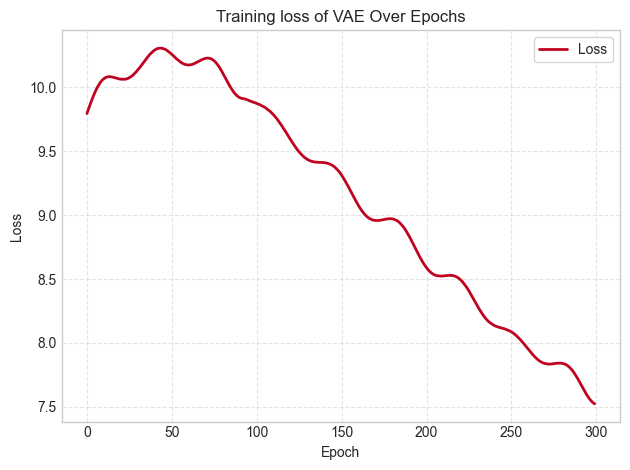

```python
monster_red = "#C00321"
plt.figure()
plt.plot(hist, label='Loss', linewidth=2, color=monster_red)
plt.xlabel('Epoch')
plt.ylabel('Loss')
plt.title('Training loss of VAE Over Epochs')
plt.legend(frameon=True)
plt.grid(True, linestyle='--', alpha=0.5)
plt.tight_layout()
```

It can be seen that if we increase the number of epochs the loss function increases after the 300 epoch. So we settled for this value.

## Dataset creation for the GAN

At this point we can construct a new dataset for the training and testing of the GAN model byt using the just computed latent features of the VAE. This, as already said before, helps the GAN generalize the results and make them more stable.

First we need to evaluate the VAE model to extract the results we need.

```python
model.eval()
_, VAE_train_x, train_x_mu, train_x_var = model(torch.from_numpy(train_x).float().to(device))
_, VAE_test_x, test_x_mu, test_x_var = model(torch.from_numpy(test_x).float().to(device))
```

A sliding window function is needed when training a GAN model to account for the time dependency.

```python
def sliding_window(x, y, window):
    x_ = []
    y_ = []
    y_gan = []
    for i in range(window, x.shape[0]):
        tmp_x = x[i - window: i, :]
        tmp_y = y[i]
        tmp_y_gan = y[i - window: i + 1]
        x_.append(tmp_x)
        y_.append(tmp_y)
        y_gan.append(tmp_y_gan)
    x_ = torch.from_numpy(np.array(x_)).float()
    y_ = torch.from_numpy(np.array(y_)).float()
    y_gan = torch.from_numpy(np.array(y_gan)).float()
    return x_, y_, y_gan
```

Creation of the new dataset

```python
train_x = np.concatenate((train_x, VAE_train_x.cpu().detach().numpy()), axis = 1)
test_x = np.concatenate((test_x, VAE_test_x.cpu().detach().numpy()), axis = 1)
```

```python
train_x_slide, train_y_slide, train_y_gan = sliding_window(train_x, train_y, 3)
test_x_slide, test_y_slide, test_y_gan = sliding_window(test_x, test_y, 3)
print(f'train_x: {train_x_slide.shape} train_y: {train_y_slide.shape} train_y_gan: {train_y_gan.shape}')
print(f'test_x: {test_x_slide.shape} test_y: {test_y_slide.shape} test_y_gan: {test_y_gan.shape}')
```

```
train_x: torch.Size([561, 3, 21]) train_y: torch.Size([561, 1]) train_y_gan: torch.Size([561, 4, 1])
test_x: torch.Size([138, 3, 21]) test_y: torch.Size([138, 1]) test_y_gan: torch.Size([138, 4, 1])
```

A GAN is made up from 2 distinct entities which interact with each other in order to make the model work. The model can be understood as a pair of a counterfeiter and a police officer and a valuable piece of art. The first (the generator) aims to replicate the work of art as closely as possibly and its only feedback is the feedback the police officer gives him. The latter aims to maximize the probability of discovering the counterfeited art piece.

We use Gated Recurrent Units (GRUs) as the main building blocks of the generator network: why?

- **Using temporal dependencies:** GRUs are designed for sequential data. They effectively capture long- and short-term dependencies in time series without the complexity of LSTMs.
- **Efficiency:** Compared to LSTMs, GRUs have fewer parameters and are faster to train.
- **Stability:** Recurrent architectures like GRUs are more stable than CNNs or fully connected networks when modeling noisy time series data, especially within a GAN setup.

```python
class Generator(nn.Module):
    def __init__(self, input_size):
        super().__init__()
        self.gru_1 = nn.GRU(input_size, 1024, batch_first = True)
        self.gru_2 = nn.GRU(1024, 512, batch_first = True)
        self.gru_3 = nn.GRU(512, 256, batch_first = True)
        self.linear_1 = nn.Linear(256, 128)
        self.linear_2 = nn.Linear(128, 64)
        self.linear_3 = nn.Linear(64, 1)
        self.dropout = nn.Dropout(0.2)

    def forward(self, x):
        use_cuda = 1
        device = torch.device("cuda" if (torch.cuda.is_available() & use_cuda) else "cpu")
        h0 = torch.zeros(1, x.size(0), 1024).to(device)
        out_1, _ = self.gru_1(x, h0)
        out_1 = self.dropout(out_1)
        h1 = torch.zeros(1, x.size(0), 512).to(device)
        out_2, _ = self.gru_2(out_1, h1)
        out_2 = self.dropout(out_2)
        h2 = torch.zeros(1, x.size(0), 256).to(device)
        out_3, _ = self.gru_3(out_2, h2)
        out_3 = self.dropout(out_3)
        out_4 = self.linear_1(out_3[:, -1, :])
        out_5 = self.linear_2(out_4)
        out = self.linear_3(out_5)
        return out

class Discriminator(nn.Module):
    def __init__(self):
        super().__init__()
        self.conv1 = nn.Conv1d(4, 32, kernel_size = 3, stride = 1, padding = 'same')
        self.conv2 = nn.Conv1d(32, 64, kernel_size = 3, stride = 1, padding = 'same')
        self.conv3 = nn.Conv1d(64, 128, kernel_size = 3, stride = 1, padding = 'same')
        self.linear1 = nn.Linear(128, 220)
        self.batch1 = nn.BatchNorm1d(220)
        self.linear2 = nn.Linear(220, 220)
        self.batch2 = nn.BatchNorm1d(220)
        self.linear3 = nn.Linear(220, 1)
        self.leaky = nn.LeakyReLU(0.01)
        self.relu = nn.ReLU()
        self.sigmoid = nn.Sigmoid()

    def forward(self, x):
        conv1 = self.conv1(x)
        conv1 = self.leaky(conv1)
        conv2 = self.conv2(conv1)
        conv2 = self.leaky(conv2)
        conv3 = self.conv3(conv2)
        conv3 = self.leaky(conv3)
        flatten_x = conv3.reshape(conv3.shape[0], conv3.shape[1])
        out_1 = self.linear1(flatten_x)
        out_1 = self.leaky(out_1)
        out_2 = self.linear2(out_1)
        out_2 = self.relu(out_2)
        out_3 = self.linear3(out_2)
        out = self.sigmoid(out_3)
        return out
```

The BCE loss is a basic choice when training a discriminator that outputs a probability indicating whether a sample is real or fake.

- **Discriminator Loss:** $$ \mathcal{L}_D = -\mathbb{E}[\log D(x_{\text{real}})] - \mathbb{E}[\log (1 - D(x_{\text{fake}}))] $$ The discriminator learns to maximize the probability of assigning the correct label (1 for real, 0 for fake).
- **Generator Loss:** $$ \mathcal{L}_G = -\mathbb{E}[\log D(x_{\text{fake}})] $$ The generator tries to produce samples that the discriminator classifies as real (i.e., wants that $D(x_{\text{fake}}) \to 1 $).

#### Why?

The training is faster than more complicated loss functions and is useful in constructing a basic model to later evaluate WGAN.

```python
use_cuda = 1
device = torch.device("cuda" if (torch.cuda.is_available() & use_cuda) else "cpu")

batch_size = 128
learning_rate = 0.00016
num_epochs = 165

trainDataloader = DataLoader(TensorDataset(train_x_slide, train_y_gan), batch_size = batch_size, shuffle = False)

modelG = Generator(21).to(device)
modelD = Discriminator().to(device)

criterion = nn.BCELoss()
optimizerG = torch.optim.Adam(modelG.parameters(), lr = learning_rate, betas = (0.0, 0.9))
optimizerD = torch.optim.Adam(modelD.parameters(), lr = learning_rate, betas = (0.0, 0.9))

histG = np.zeros(num_epochs)
histD = np.zeros(num_epochs)
count = 0
for epoch in range(num_epochs):
    loss_G = []
    loss_D = []
    for (x, y) in trainDataloader:
        x = x.to(device)
        y = y.to(device)

        fake_data = modelG(x)
        fake_data = torch.cat([y[:, :3, :], fake_data.reshape(-1, 1, 1)], axis = 1)

        dis_real_output = modelD(y)
        real_labels = torch.ones_like(dis_real_output).to(device)
        lossD_real = criterion(dis_real_output, real_labels)


        dis_fake_output = modelD(fake_data)
        fake_labels = torch.zeros_like(real_labels).to(device)
        lossD_fake = criterion(dis_fake_output, fake_labels)

        lossD = (lossD_real + lossD_fake)

        modelD.zero_grad()
        lossD.backward(retain_graph=True)
        optimizerD.step()
        loss_D.append(lossD.item())

        output_fake = modelD(fake_data)
        lossG = criterion(output_fake, real_labels)
        modelG.zero_grad()
        lossG.backward()
        optimizerG.step()
        loss_G.append(lossG.item())
    histG[epoch] = sum(loss_G)
    histD[epoch] = sum(loss_D)
    print(f'[{epoch+1}/{num_epochs}] LossD: {sum(loss_D)} LossG:{sum(loss_G)}')
```

```
[1/165] LossD: 6.9369776248931885 LossG:3.3075591921806335
[2/165] LossD: 6.933488368988037 LossG:3.364501416683197
[3/165] LossD: 6.933173179626465 LossG:3.408754825592041
[4/165] LossD: 6.931530833244324 LossG:3.4388691782951355
[5/165] LossD: 6.9312920570373535 LossG:3.4553009271621704
[6/165] LossD: 6.9311957359313965 LossG:3.4626688957214355
[7/165] LossD: 6.931238293647766 LossG:3.4650712609291077
[8/165] LossD: 6.931078314781189 LossG:3.4659987688064575
[9/165] LossD: 6.931025743484497 LossG:3.466090500354767
[10/165] LossD: 6.9311206340789795 LossG:3.466172516345978
[11/165] LossD: 6.931145787239075 LossG:3.4663045406341553
[12/165] LossD: 6.9312744140625 LossG:3.4662352204322815
[13/165] LossD: 6.931260585784912 LossG:3.4664735198020935
[14/165] LossD: 6.931284666061401 LossG:3.466547429561615
[15/165] LossD: 6.931232571601868 LossG:3.46641743183136
[16/165] LossD: 6.931174993515015 LossG:3.466349244117737
[17/165] LossD: 6.931115031242371 LossG:3.466401994228363
[18/165] LossD: 6.931089878082275 LossG:3.4662585258483887
[19/165] LossD: 6.930994868278503 LossG:3.4679166674613953
[20/165] LossD: 6.931015372276306 LossG:3.4655531644821167
[21/165] LossD: 6.9309821128845215 LossG:3.466960847377777
[22/165] LossD: 6.9309974908828735 LossG:3.4663819670677185
[23/165] LossD: 6.93100905418396 LossG:3.466517448425293
[24/165] LossD: 6.931018829345703 LossG:3.466444969177246
[25/165] LossD: 6.9310678243637085 LossG:3.466415822505951
[26/165] LossD: 6.931112885475159 LossG:3.4663305282592773
[27/165] LossD: 6.9312684535980225 LossG:3.466139018535614
[28/165] LossD: 6.930883169174194 LossG:3.466934621334076
[29/165] LossD: 6.930707097053528 LossG:3.466740369796753
[30/165] LossD: 6.931030869483948 LossG:3.4665988087654114
[31/165] LossD: 6.931280732154846 LossG:3.4662232398986816
[32/165] LossD: 6.930067420005798 LossG:3.4680484533309937
[33/165] LossD: 6.930548667907715 LossG:3.4672070145606995
[34/165] LossD: 6.930527925491333 LossG:3.4670785069465637
[35/165] LossD: 6.931081652641296 LossG:3.4663496017456055
[36/165] LossD: 6.930898308753967 LossG:3.467406749725342
[37/165] LossD: 6.929590821266174 LossG:3.468248128890991
[38/165] LossD: 6.930363655090332 LossG:3.4674869179725647
[39/165] LossD: 6.9301533699035645 LossG:3.4673895835876465
[40/165] LossD: 6.930309772491455 LossG:3.467476010322571
```

[output cut: 110 more lines]

```
[151/165] LossD: 6.851992964744568 LossG:3.5400003790855408
[152/165] LossD: 6.842021226882935 LossG:3.5261982679367065
[153/165] LossD: 6.8429114818573 LossG:3.564182698726654
[154/165] LossD: 6.872925043106079 LossG:3.4955278635025024
[155/165] LossD: 6.79753577709198 LossG:3.578728973865509
[156/165] LossD: 6.807342529296875 LossG:3.5563714504241943
[157/165] LossD: 6.845854043960571 LossG:3.56477552652359
[158/165] LossD: 6.817649483680725 LossG:3.5241793990135193
[159/165] LossD: 6.855267643928528 LossG:3.5656906962394714
[160/165] LossD: 6.823655724525452 LossG:3.5431946516036987
[161/165] LossD: 6.82658851146698 LossG:3.5651179552078247
[162/165] LossD: 6.8344361782073975 LossG:3.5221453309059143
[163/165] LossD: 6.784965991973877 LossG:3.6042598485946655
[164/165] LossD: 6.8621344566345215 LossG:3.515088140964508
[165/165] LossD: 6.766133785247803 LossG:3.5539698004722595
```

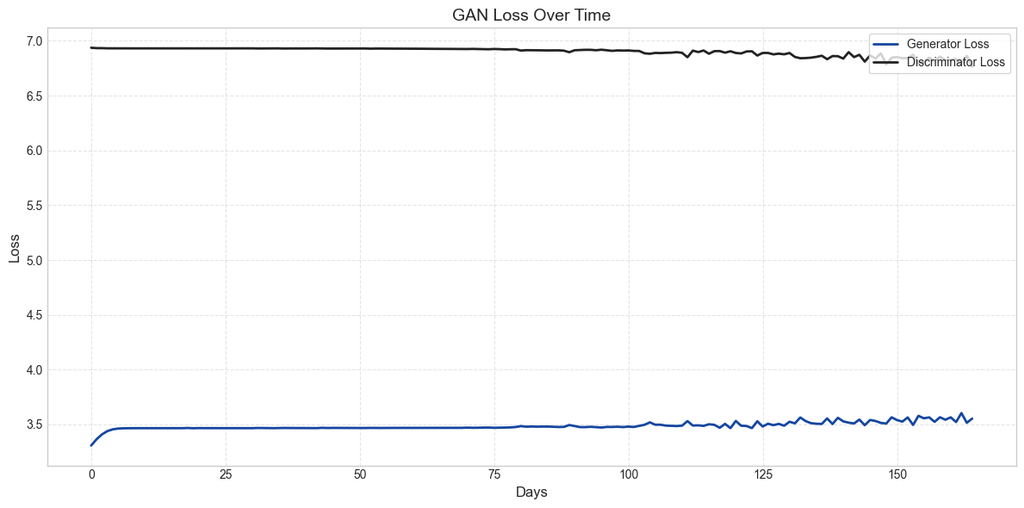

```python
gen_color = "#1446A0"
disc_color = "#222222"
plt.figure(figsize=(12, 6))
plt.plot(histG, color=gen_color, label='Generator Loss', linewidth=2)
plt.plot(histD, color=disc_color, label='Discriminator Loss', linewidth=2)
plt.title('GAN Loss Over Time', fontsize=14)
plt.xlabel('Days', fontsize=12)
plt.ylabel('Loss', fontsize=12)
plt.legend(loc='upper right', frameon=True)
plt.grid(True, linestyle='--', alpha=0.5)
plt.tight_layout()
```

The loss function does seems to converge but this does not decrease. This may seems off but it may be because the GAN reached an equilibrium where the generator produces results which are more or less realistic to fool the discriminator. The discriminator manages to distinguish between real and fake with a certain margin of success.

## GAN testing

```python
modelG.eval()
pred_y_train = modelG(train_x_slide.to(device))
pred_y_test = modelG(test_x_slide.to(device))

y_train_true = y_scaler.inverse_transform(train_y_slide)
y_train_pred = y_scaler.inverse_transform(pred_y_train.cpu().detach().numpy())

y_test_true = y_scaler.inverse_transform(test_y_slide)
y_test_pred = y_scaler.inverse_transform(pred_y_test.cpu().detach().numpy())
```

```
Training dataset RMSE: 0.0753
```

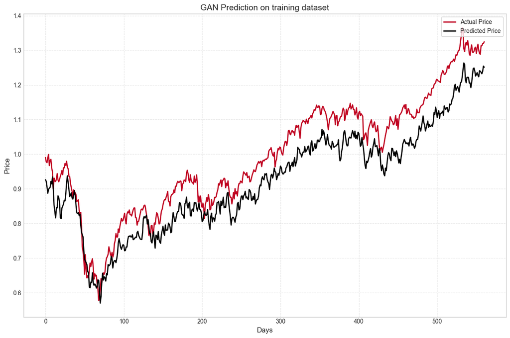

```python
actual_color = "#C00321"
pred_color = "#000000"
plt.figure(figsize=(12, 8))
plt.plot(y_train_true, color=actual_color, label='Actual Price', linewidth=2)
plt.plot(y_train_pred, color=pred_color, label='Predicted Price', linewidth=2)
plt.title('GAN Prediction on training dataset', fontsize=14)
plt.xlabel('Days', fontsize=12)
plt.ylabel('Price', fontsize=12)
plt.legend(loc='upper right', frameon=True)
plt.grid(True, linestyle='--', alpha=0.5)
plt.tight_layout()
MSE = mean_squared_error(y_train_true, y_train_pred)
RMSE = math.sqrt(MSE)
print(f'Training dataset RMSE: {RMSE:.4f}')
```

```
Testing dataset RMSE: 0.1417
```

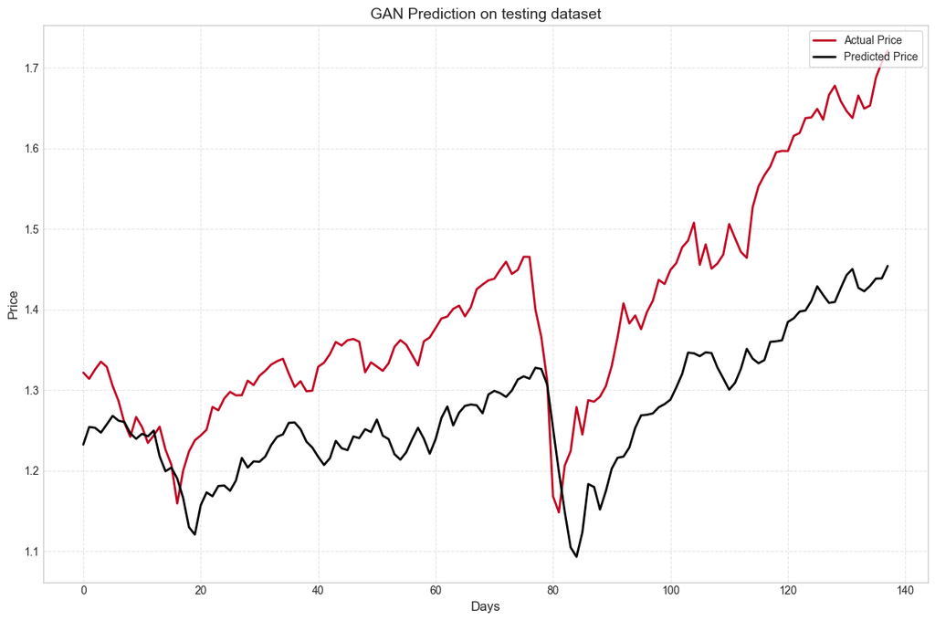

```python
plt.figure(figsize=(12, 8))
plt.plot(y_test_true, color=actual_color, label='Actual Price', linewidth=2)
plt.plot(y_test_pred, color=pred_color, label='Predicted Price', linewidth=2)
plt.title('GAN Prediction on testing dataset', fontsize=14)
plt.xlabel('Days', fontsize=12)
plt.ylabel('Price', fontsize=12)
plt.legend(loc='upper right', frameon=True)
plt.grid(True, linestyle='--', alpha=0.5)
plt.tight_layout()
MSE = mean_squared_error(y_test_true, y_test_pred)
RMSE = math.sqrt(MSE)
print(f'Testing dataset RMSE: {RMSE:.4f}')
```

From what we can see there is a lot of room for improvement in this basic model in terms of tracking ability of the GAN. This is in line with our line of thought of it being just a baseline model.

At last we computed the Historical VaR using a rolling window approach.

```
Average Historical VaR 95%: 0.0250
Average Historical VaR 99% (last point): 0.0314
```

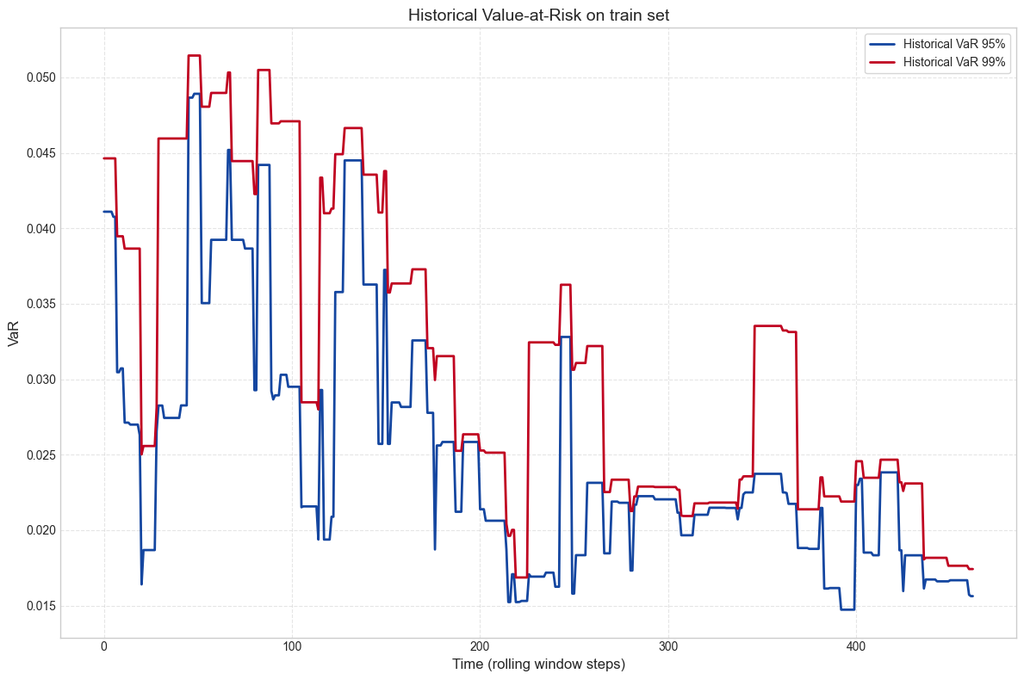

```python
rolling = 48
Returns1 = (y_train_pred[rolling+1:] / y_train_pred[rolling:-1]) - 1
SampleSize = len(Returns1)

pVAR = [0.05, 0.01]

Historical95 = []
Historical99 = []
EstimationWindowSize = int(rolling / 2)

for t in range(rolling + 1, len(Returns1)):
    y = Returns1[(t - EstimationWindowSize):(t-1)]

    Historical95.append(np.quantile(y, 0.95))
    Historical99.append(np.quantile(y, 0.99))

plt.figure(figsize=(12, 8))

plt.plot(Historical95, label='Historical VaR 95%', linewidth=2, color="#1446A0")
plt.plot(Historical99, label='Historical VaR 99%', linewidth=2, color="#C00321")

plt.title('Historical Value-at-Risk on train set', fontsize=14)
plt.xlabel('Time (rolling window steps)', fontsize=12)
plt.ylabel('VaR', fontsize=12)

plt.legend(loc='upper right', frameon=True)
plt.grid(True, linestyle='--', alpha=0.5)
plt.tight_layout()
print(f'Average Historical VaR 95%: {np.mean(Historical95):.4f}')
print(f'Average Historical VaR 99% (last point): {np.mean(Historical99):.4f}')
```

```
Average Historical VaR 95% (last point): 0.0191
Average Historical VaR 99% (last point): 0.0218
```

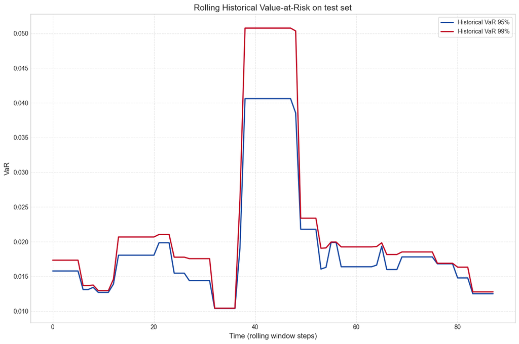

```python
rolling = 24
Returns1 = (y_test_pred[rolling+1:] / y_test_pred[rolling:-1]) - 1
SampleSize = len(Returns1)

pVAR = [0.05, 0.01]

Historical95 = []
Historical99 = []
EstimationWindowSize = int(rolling / 2)

for t in range(rolling + 1, len(Returns1)):
    y = Returns1[(t - EstimationWindowSize):(t-1)]

    Historical95.append(np.quantile(y, 0.95))
    Historical99.append(np.quantile(y, 0.99))

plt.figure(figsize=(12, 8))

plt.plot(Historical95, label='Historical VaR 95%', linewidth=2, color="#1446A0")
plt.plot(Historical99, label='Historical VaR 99%', linewidth=2, color="#C00321")

plt.title('Rolling Historical Value-at-Risk on test set', fontsize=14)
plt.xlabel('Time (rolling window steps)', fontsize=12)
plt.ylabel('VaR', fontsize=12)

plt.legend(loc='upper right', frameon=True)
plt.grid(True, linestyle='--', alpha=0.5)
plt.tight_layout()

# Print last-point averages
print(f'Average Historical VaR 95% (last point): {np.mean(Historical95):.4f}')
print(f'Average Historical VaR 99% (last point): {np.mean(Historical99):.4f}')
```

What we see is that the function is step-wise which is in line that, after a new prediction is made, it is certain that the quantile it changes. Since the GAN is a black-box model we lose the possibility of taking into account transaction costs but the model we obtain has better performance than the white-box models (Ridge, Lasso, Kalman Filter, Elastic Net).